# SciPy 2015

Austin, TX, July 6 - 12

## Conference structure

This conference is different. The audience is mostly people working in science, but many people working in tech and software development. It's a very diverse crowd, and they are *friendly*.

- 2 days of tutorials
- 3 days of main conference: 3 simultaneous tracks of talks + poster session + lightning talks
  - plenty of social events each evening
  - a job fair
- 2 days of sprints

## Tutorials

I attended a variety of tutorials. The ones I enjoyed the most were:

- Machine Learning with Scikit-Learn (2 sessions)
- Building Python Data Applications with Bokeh and Blaze

## Machine Learning with Scikit-Learn

The full tutorial materials can be found here: https://github.com/amueller/scipy_2015_sklearn_tutorial

This was a 2-session (8 hour) tutorial; it covered a host of topics:

## Morning Session

- What is machine learning?
- Supervised learning
  - Training and test data
  - Classification
  - Regression
- Unsupervised Learning
  - Unsupervised transformers
  - Preprocessing and scaling
  - Dimensionality reduction
  - Clustering

### Application : Classification of digits

```python
from sklearn.datasets import load_digits
digits = load_digits()
%matplotlib inline
import matplotlib.pyplot as plt
```

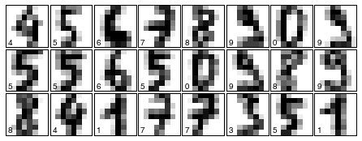

```python
fig = plt.figure(figsize=(6, 6))  # figure size in inches
fig.subplots_adjust(left=0, right=1, bottom=0, top=1, hspace=0.05, wspace=0.05)

# plot the digits: each image is 8x8 pixels
for i in range(24, 48):
    ax = fig.add_subplot(8, 8, i + 1, xticks=[], yticks=[])
    ax.imshow(digits.images[i], cmap=plt.cm.binary, interpolation='nearest')

    # label the image with the target value
    ax.text(0, 7, str(digits.target[i]))
```

We can train, for example, a Gaussian Naive Bayes classifier to identify digits from a test set.

```python
from sklearn.naive_bayes import GaussianNB
from sklearn.cross_validation import train_test_split
```

```python
digits.data.shape
```

```
(1797, 64)
```

```python
# split the data into training and validation sets
X_train, X_test, y_train, y_test = train_test_split(digits.data, digits.target, random_state=5)

# train the model
clf = GaussianNB()
clf.fit(X_train, y_train)

# use the model to predict the labels of the test data
predicted = clf.predict(X_test)
expected = y_test
```

How did we do?

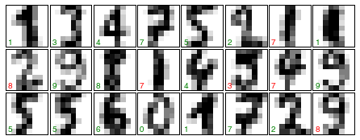

```python
fig = plt.figure(figsize=(6, 6))  # figure size in inches
fig.subplots_adjust(left=0, right=1, bottom=0, top=1, hspace=0.05, wspace=0.05)

# plot the digits: each image is 8x8 pixels
for i in range(24,48):
    ax = fig.add_subplot(8, 8, i + 1, xticks=[], yticks=[])
    ax.imshow(X_test.reshape(-1, 8, 8)[i], cmap=plt.cm.binary,
              interpolation='nearest')

    # label the image with the target value
    if predicted[i] == expected[i]:
        ax.text(0, 7, str(predicted[i]), color='green')
    else:
        ax.text(0, 7, str(predicted[i]), color='red')
```

```python
print(clf.score(X_test, y_test))
```

```
0.811111111111
```

### Application: Eigenfaces

```python
from sklearn import datasets
lfw_people = datasets.fetch_lfw_people(min_faces_per_person=70, resize=0.4,
                                       data_home='../tutorials/scipy_2015_sklearn_tutorial/notebooks/datasets/')
lfw_people.data.shape
```

```
(1288, 1850)
```

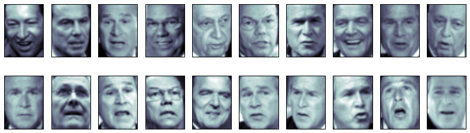

```python
fig = plt.figure(figsize=(14, 4))
# plot several images
for i in range(20):
    ax = fig.add_subplot(2, 10, i + 1, xticks=[], yticks=[])
    ax.imshow(lfw_people.images[i], cmap=plt.cm.bone)
```

We can perform PCA to extract features from the set of images:

```python
from sklearn.cross_validation import train_test_split
X_train, X_test, y_train, y_test = train_test_split(
                                        lfw_people.data,
                                        lfw_people.target,
                                        random_state=0)

print(X_train.shape, X_test.shape)
```

```
(966, 1850) (322, 1850)
```

```python
from sklearn import decomposition
pca = decomposition.RandomizedPCA(n_components=150, whiten=True)
pca.fit(X_train)
```

```
RandomizedPCA(copy=True, iterated_power=3, n_components=150,
       random_state=None, whiten=True)
```

And we can view the mean face:

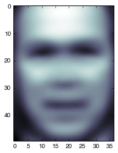

```python
plt.imshow(pca.mean_.reshape((50, 37)), cmap=plt.cm.bone)
```

As well as the eigenfaces, if we like:

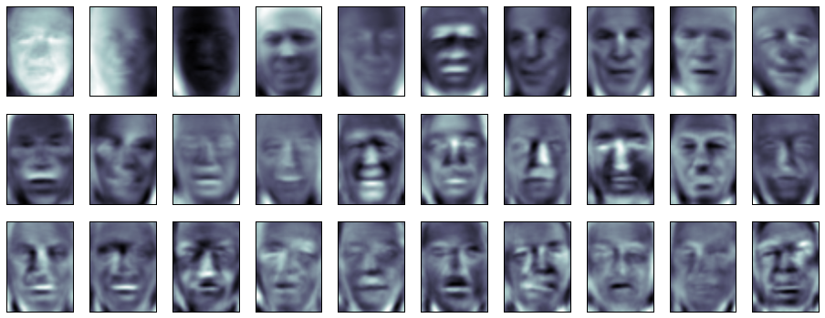

```python
fig = plt.figure(figsize=(16, 6))
for i in range(30):
    ax = fig.add_subplot(3, 10, i + 1, xticks=[], yticks=[])
    ax.imshow(pca.components_[i].reshape((50, 37)), cmap=plt.cm.bone)
```

And plenty more example activities:

- Methods: Text feature abstraction, bag of words
- Application : SMS spam detection
- Summary : Model building and generalization

## Afternoon Session

- Cross-Validation
- Model Complexity: Overfitting and underfitting
- Complexity of various model types
- Grid search for adjusting hyperparameters
- Basic regression with cross-validation
- Application : Titanic survival with Random Forest
- Building Pipelines
  - Motivation and Basics
  - Preprocessing and Classification
  - Grid-searching Parameters of the feature extraction

And plenty of examples:

- Application : Image classification
- Model complexity, learning curves and validation curves
- In-Depth supervised models
  - Linear Models
  - Kernel SVMs
  - trees and Forests
- Learning with Big Data
  - Out-Of-Core learning
  - The hashing trick for large text corpuses

## Building Python Data Applications with Blaze and Bokeh

The full tutorial materials can be found here: https://github.com/chdoig/scipy2015-blaze-bokeh

This session covered mainly Bokeh's API, which allows one to easily build interactive plots that can be rendered in a browser.

```python
import pandas as pd
from bokeh.plotting import figure, show, output_notebook
output_notebook()

# Get data
df = pd.read_csv('../tutorials/scipy2015-blaze-bokeh/data/Land_Ocean_Monthly_Anomaly_Average.csv')

# Process data
df['datetime'] = pd.to_datetime(df['datetime'])
df.head()
```

BokehJS successfully loaded.

|  | datetime | anomaly | uncert |
| --- | --- | --- | --- |
| 0 | 1850-01-01 | -0.699 | 0.411 |
| 1 | 1850-02-01 | -0.210 | 0.469 |
| 2 | 1850-03-01 | -0.349 | 0.377 |
| 3 | 1850-04-01 | -0.625 | 0.319 |
| 4 | 1850-05-01 | -0.594 | 0.317 |

```python
# Create plot
f = figure(plot_width=800, plot_height=400)
f.line(df['datetime'], df['anomaly'], color='skyblue', legend='Temp')
f.line(df['datetime'], pd.rolling_mean(df['anomaly'], window=10), color='grey', legend='Rolling mean')
f.title = 'Temperature anomaly with time'

# Show plot
show(f)
```

[output not shown]

## My favorite talks

There were a ton of great talks, and quite a few relevant to the stuff we do. Here's a selection of ones that stood out to me, with links.

### Dask

Dask provides data structures that can do complex out-of-core operations with an API similar to numpy and pandas.

- Talk: https://youtu.be/1kkFZ4P-XHg

```python
from datetime import timedelta
from IPython.display import YouTubeVideo
start=int(timedelta(minutes=7, seconds=45).total_seconds())
YouTubeVideo("1kkFZ4P-XHg", start=start, autoplay=0, theme="light",
             color="blue", height=400, width=700)
```

[video not shown]

### HDF5 is Eating the World

A talk on HDF5 by the author of h5py on ways to use HDF5 effectively.

- Talk: https://youtu.be/nddj5OA8LJo

### Deep Learning: Tips from the Road

A talk by Kyle Kastner (one of the scikit-learn tutorial instructors) on deep learning, its uses, and its limitations. A great, short intro to neural networks.

- Talk: https://youtu.be/TBBtOeY2Q78

```python
from datetime import timedelta
from IPython.display import YouTubeVideo
start=int(timedelta(minutes=0, seconds=40).total_seconds())
YouTubeVideo("TBBtOeY2Q78", start=start, autoplay=0, theme="light",
             color="red", height=400, width=700)
```

[video not shown]

### Agent Based Modeling in Python with Mesa

A talk by the authors of Mesa, a new package that fills a hole in the python ecosystem: a package for building agent-based simulations.

- Talk: https://youtu.be/lcySLoprPMc
- Project: https://github.com/projectmesa/mesa

### VisPy: Harnessing The GPU For Fast, High Level Visualization

Great talk by Luke Campagnola on the capabilities of VisPy to generate complex visualizations in real time using the GPU and OpenGL.

- Talk: https://youtu.be/_3YoaeoiIFI
- Project: http://vispy.org/

```python
from datetime import timedelta
from IPython.display import YouTubeVideo
start=int(timedelta(minutes=11, seconds=43).total_seconds())
YouTubeVideo("_3YoaeoiIFI", start=start, autoplay=0, theme="light",
             color="red", height=400, width=700)
```

[video not shown]

## And many more!

- Time Series Analysis for Network Security: https://youtu.be/ZSM-tmbBZ5E
- Statistical Thinking for Data Science: https://youtu.be/TGGGDpb04Yc
- xray: ND Labeled Arrays and Datasets: https://youtu.be/X0pAhJgySxk
- RESTful HDF: https://youtu.be/JSFZ3i3WcjQ
- Teaching with IPython/Jupyter Notebooks and JupyterHub: https://youtu.be/OuhtpxGuboY
- Accelerating Python with the Numba JIT Compiler: https://youtu.be/eYIPEDnp5C4

## Great keynotes!

There were three keynote talks, one given each day of the main conference. All three are worth watching:

- Data Science at the New York Times by Chris Wiggins: https://youtu.be/MNosMXFGtBE
- My Data Journey with Python by Wes McKinney: https://youtu.be/kHdkFyGCxiY
- State of the Tools by Jake VanderPlaas: https://youtu.be/5GlNDD7qbP4

## Things I missed (but will watch on YouTube later)

- Computational Statistics tutorial (2 days) by Allen Downey and Chris Fonnesbeck: https://youtu.be/fMycLa1bsno and https://youtu.be/heFaYLKVZY4
- Cython tutorial: https://youtu.be/gMvkiQ-gOW8
- Jupyter : Ipython, State Of Multiuser And Real Time Collaboration: https://youtu.be/DyGoHAP8B_s
- PyStruct Structured Prediction in Python: https://www.youtube.com/watch?v=12eMr1ZeMI4

## Things I missed (but will watch on YouTube later)

- Big Data in Practice The Example of Nilearn for Mining Brain Imaging Data: https://www.youtube.com/watch?v=wsnWCo1yAXw
- Keep on Releasin' Continuous Delivery for Open Source: https://youtu.be/x8feIJTJRXY
- A Better Default Colormap for Matplotlib: https://youtu.be/xAoljeRJ3lU

## Things I missed (but will watch on YouTube later)

- Story Time with Bokeh: https://youtu.be/c9CgHHz_iYk
- many other talks that ran in parallel; check out the full playlist here: https://www.youtube.com/playlist?list=PLYx7XA2nY5Gcpabmu61kKcToLz0FapmHu

## Most important:

- New contacts: met a lot of people I'm already working with on new projects.
- New ideas: plenty of raw material to work with.
- Inspiration! When you're excited about working on things, that's the first step to doing something cool.